# Project 1

## Transforming the continous variable into catagorical

7. Transform cleaned age variable into broad age groups i.e. <15, 15-59, 60+ years, define it as factor variable and get number and percentage of this variable and interpret it carefully

### Creating a new categorical variable from age

```r
covidtbl<-within(covidtbl,{
  age.cat<-NA
  age.cat[age<15]<-"<15"
  age.cat[age>=15 & age<60]<-'15-59'
  age.cat[age>=60]<-'60+'
})
```

### Converting the new variable into factor.

```r
covidtbl$age.cat <- factor(covidtbl$age.cat, levels = c("<15", "15-59", "60+"))
summary(covidtbl$age.cat)
```

```
##   <15 15-59   60+
##    77 77476   264
```

```r
uage<-as.data.frame(table(covidtbl$age.cat))
uage$percentage<-(uage$Freq/sum(uage$Freq))*100
uage
```

| Var1 | Freq | percentage |
| --- | --- | --- |
| <15 | 77 | 0.0989501 |
| 15-59 | 77476 | 99.5617924 |
| 60+ | 264 | 0.3392575 |

As we can see that the about 99.5% of reported cases were in the age group of 15 to 59. It seems realistic as the covid in Nepal first broke out in the cluster of people who worked outside and country and returned after pandemic. Most test was also done in the same cluster.

## Finding difference between recovered and reported dates

8. Find the number of days between recovered and reported dates (define it as: diff1 variable), clean it if required, and get the summary statistics of this variable and interpret it carefully

### Getting the difference in days

```r
covidtbl$diff1<-as.numeric(difftime(covidtbl$recoveredOn, covidtbl$reportedOn, units = "days"))
```

### Getting of summary

```r
summary(covidtbl$diff1)
```

```
##    Min. 1st Qu.  Median    Mean 3rd Qu.    Max.    NA's
##    0.00    1.00   15.00   17.26   27.00  179.00   21389
```

## Finding the Difference between reported date and death date

9. Find the number of days between deaths and reported dates (define it as: diff2 variable), clean it if required, and get the summary statistics of this variable and interpret it carefully

### Getting the difference in days

```r
covidtbl$diff2<-as.numeric(difftime(covidtbl$deathOn, covidtbl$reportedOn, units = "days"))
```

### Geting the Summary of New variable

```r
summary(covidtbl$diff2)
```

```
##    Min. 1st Qu.  Median    Mean 3rd Qu.    Max.    NA's
##   -8.00    1.00    6.00   17.79   26.00  163.00   77319
```

The Minimum value is -8 which is kind of odd. Lets check the rows with negative difference.

```r
library(dplyr)
filter(covidtbl,diff2<0)
```

| id | province | district | municipality | createdOn | modifiedOn | label | gender | age | occupation | reportedOn | recoveredOn | deathOn | currentState | isReinfected | source | comment | type | nationality | ward | age.cat | diff1 | diff2 |
| --- | --- | --- | --- | --- | --- | --- | --- | --- | --- | --- | --- | --- | --- | --- | --- | --- | --- | --- | --- | --- | --- | --- |
| 10756 | 5 | 40 | 51006 | 2020-06-12T18:04:02.340393+05:45 | 2020-06-12T18:56:15.913439+05:45 | COV-NPL-4898 | male | 57 | NA | 2020-06-12 |  | 2020-06-10 | death | FALSE | https://www.mohp.gov.np/eng/ |  | NA | NA | 33 | 15-59 | NA | -2 |
| 290 | 3 | 24 | 23010 | 2020-05-16T21:13:06.493373+05:45 | 2020-05-16T21:26:01.116916+05:45 | COV-NPL-281 | female | 29 | NA | 2020-05-16 |  | 2020-05-14 | death | FALSE | http://www.mohp.gov.np/en |  | NA | NA | 2961 | 15-59 | NA | -2 |
| 692 | 2 | 33 | 33005 | 2020-05-25T17:01:10.708137+05:45 | 2020-05-25T17:01:10.708400+05:45 | COV-NPL-682 | male | 70 | NA | 2020-05-25 |  | 2020-05-17 | death | FALSE | https://www.mohp.gov.np/eng/ | Bara kalaila 7 | NA | NA | 6673 | 60+ | NA | -8 |
| 1113 | 5 | 40 | 51001 | 2020-05-29T17:23:12.802233+05:45 | 2020-05-29T18:03:39.496446+05:45 | COV-NPL-1102 | male | 35 | NA | 2020-05-29 |  | 2020-05-23 | death | FALSE | https://www.mohp.gov.np/eng/ | Died on Jestha 10 while coming from India. \r\nHis sample was taken on Jestha 11 and is proved positive on May 29 Media briefing. \r\nNews at 12 minute 10 second in facebook live media briefing of MoH… | NA | NA | 42 | 15-59 | NA | -6 |
| 1439 | 6 | 63 | 60003 | 2020-05-31T17:13:51.465977+05:45 | 2020-05-31T17:18:05.125929+05:45 | COV-NPL-1428 | male | 35 | NA | 2020-05-31 |  | 2020-05-30 | death | FALSE | https://www.mohp.gov.np/eng/ |  | NA | NA | 1900 | 15-59 | NA | -1 |
| 36670 | 4 | 50 | 45004 | 2020-07-06T20:38:10.593842+05:45 | 2020-07-06T20:47:30.566234+05:45 | COV-NPL-15859 | male | 29 | NA | 2020-07-06 |  | 2020-07-05 | death | FALSE | https://www.mohp.gov.np/eng/ |  | NA | NA | 5031 | 15-59 | NA | -1 |
| 6248 | 6 | 57 | 62006 | 2020-06-06T18:47:35.620753+05:45 | 2020-06-06T18:54:25.435215+05:45 | COV-NPL-3041 | male | 58 | NA | 2020-06-06 |  | 2020-06-03 | death | FALSE | https://www.mohp.gov.np/eng/ |  | NA | NA | 5439 | 15-59 | NA | -3 |
| 52836 | 3 | 27 | 27001 | 2020-08-08T16:51:09.928107+05:45 | 2020-08-08T17:52:08.270218+05:45 | COV-NPL-22565 | female | 41 | NA | 2020-08-08 |  | 2020-08-07 | death | FALSE | https://www.mohp.gov.np/eng/ |  | NA | NA | 3813 | 15-59 | NA | -1 |
| 7750 | 2 | 34 | 34011 | 2020-06-08T18:24:13.960503+05:45 | 2020-06-13T17:37:39.888241+05:45 | COV-NPL-3515 | male | 25 | NA | 2020-06-13 |  | 2020-06-10 | death | FALSE | https://www.mohp.gov.np/eng/ |  | NA | NA | 4976 | 15-59 | NA | -3 |
| 52621 | 2 | 34 | 34011 | 2020-08-08T16:51:06.541855+05:45 | 2020-08-08T17:53:58.746674+05:45 | COV-NPL-22350 | male | 74 | NA | 2020-08-08 |  | 2020-08-07 | death | FALSE | https://www.mohp.gov.np/eng/ |  | NA | NA | 4976 | 60+ | NA | -1 |

[output cut: 19 more lines]

## Appropriate Measure of Central Tendency and Dispersion

10. Which measures of central tendency and dispersion is most appropriate for the age, diff1 and diff2 variables? Why? Justify the use the appropriate measure of central tendency and dispersion by creating and interpreting the histogram and boxplot for the age, diff1 and diff2 variables and their careful interpretations

### Histogram for Age,diff1 and diff2

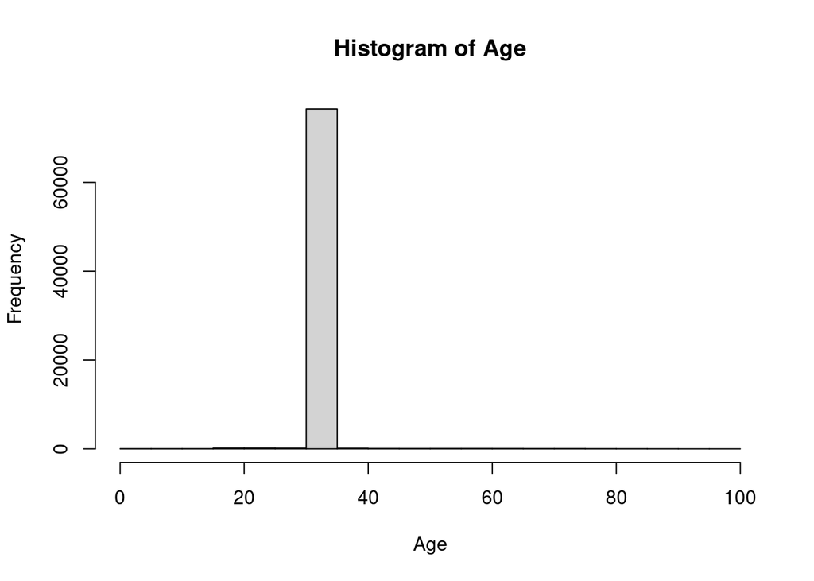

```r
hist(covidtbl$age,main = "Histogram of Age", xlab = "Age")
```

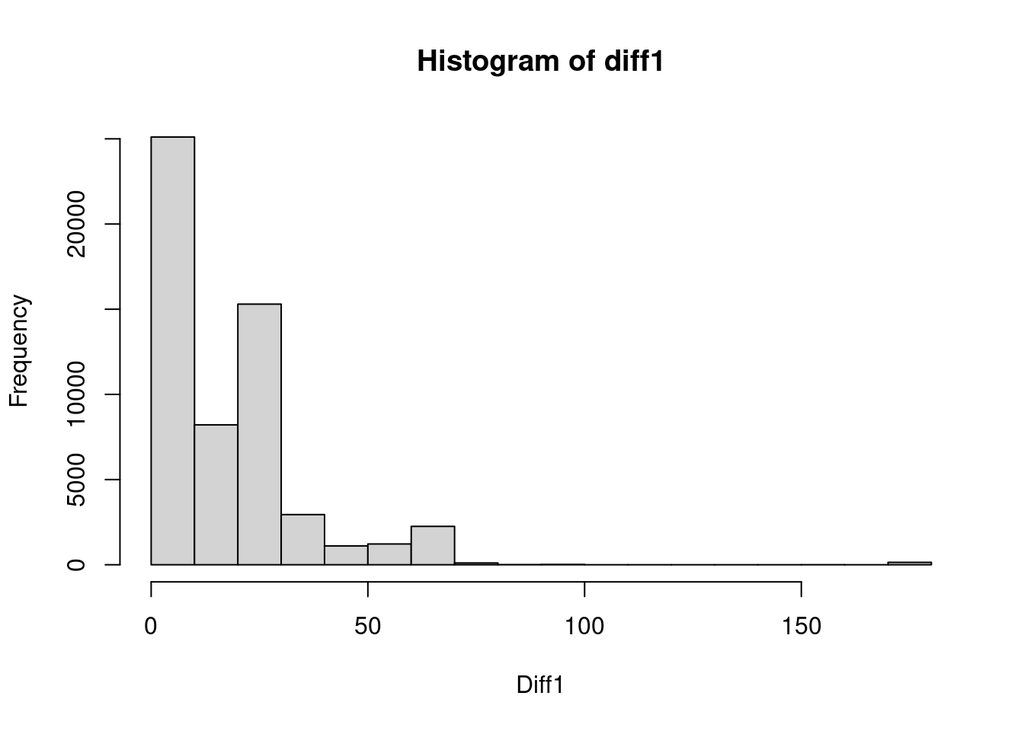

```r
hist(covidtbl$diff1,main = "Histogram of diff1",xlab="Diff1")
```

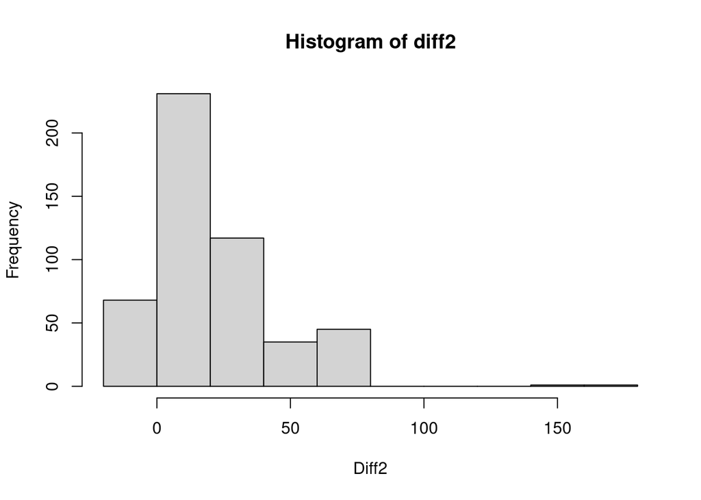

```r
hist(covidtbl$diff2,main = "Histogram of diff2", xlab = "Diff2")
```

### Boxplot for Age,diff1 and diff2

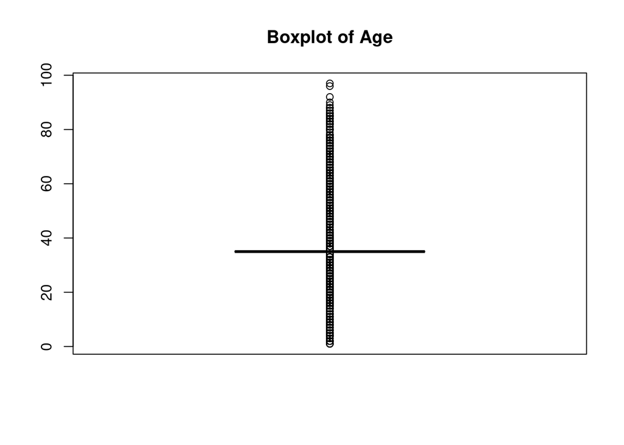

```r
boxplot(covidtbl$age,main="Boxplot of Age")
```

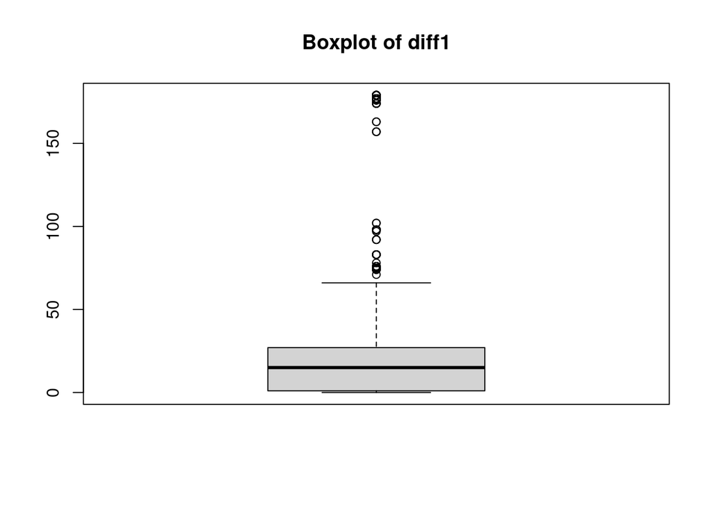

```r
boxplot(covidtbl$diff1, main="Boxplot of diff1")
```

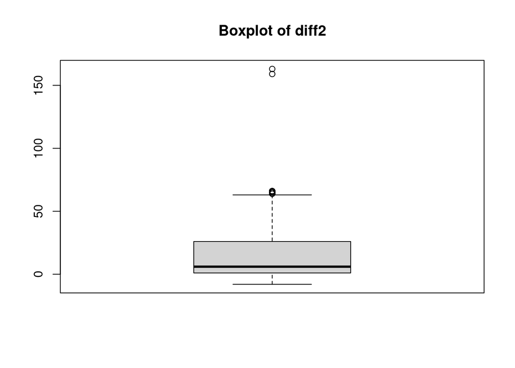

```r
boxplot(covidtbl$diff2, main="Boxplot of diff2")
```

Analyzing the graphs, we can see that the data is skewed for age, diff1 and diff2 so we have to use median for central tendency and Inter Quartile Range for dispersion.

## Analysis of current state variable

11. Show the number and percentage of the “current state” variable and interpret it carefully

```r
unique(covidtbl$currentState)
```

```
## [1] "recovered" "death"     "active"
```

```r
# Replacing the Missing value with Unknown
covidtbl$currentState[is.na(covidtbl$currentState)] <- 'unknown'
unique(covidtbl$currentState)
```

```
## [1] "recovered" "death"     "active"
```

```r
csper<-as.data.frame(table(covidtbl$currentState))
csper$percentage<-(csper$Freq/sum(csper$Freq))*100
csper
```

| Var1 | Freq | percentage |
| --- | --- | --- |
| active | 20891 | 26.846319 |
| death | 498 | 0.639963 |
| recovered | 56428 | 72.513718 |

From the result we can see that out of 77817 observations (reported case of covid) 72.5% recovered from the covid and 0.6% people died are other cases are still active as of date of collection the data.

## Analyzing the isReinfected variable

12. Show the number and percentage of the “isReinfected” variable, what percentage of cases were re-infected in Nepal at the given time period in the database? Was it realistic?

```r
summary(covidtbl$isReinfected)
```

```
##    Mode   FALSE    TRUE
## logical   77814       3
```

```r
ureinfected<-as.data.frame(table(covidtbl$isReinfected))
ureinfected$percentage<-(ureinfected$Freq/sum(ureinfected$Freq))*100
ureinfected
```

| Var1 | Freq | percentage |
| --- | --- | --- |
| FALSE | 77814 | 99.996144801 |
| TRUE | 3 | 0.003855199 |

## Analyzing type variable

13. Show the number and percentage of “type” variable and discuss the result carefully with special reference to the missing values

```r
unique(covidtbl$type)
```

```
## [1] "local_transmission" NA                   "imported"
```

```r
# Replacing the Missing value with Unknown
covidtbl$type[is.na(covidtbl$type)] <- 'unknown'
utype<-as.data.frame(table(covidtbl$type))
utype$percentage<-(utype$Freq/sum(utype$Freq))*100
utype
```

| Var1 | Freq | percentage |
| --- | --- | --- |
| imported | 22 | 0.02827146 |
| local_transmission | 16 | 0.02056106 |
| unknown | 77779 | 99.95116748 |

In this variable, we have more than 99 percentage of data as missing(NA). This means that we were not able to track where the people got covid from.

## Analyzing Nationality variable

14. Show the number and percentage of “nationality” variable and discuss the result carefully with special reference to the missing values

```r
unique(covidtbl$nationality)
```

```
## [1]  3 NA  2  4
```

```r
# Replacing the Missing value with Unknown
covidtbl$nationality[is.na(covidtbl$nationality)] <- 'unknown'
unationality<-as.data.frame(table(covidtbl$nationality))
unationality$percentage<-(unationality$Freq/sum(unationality$Freq))*100
unationality
```

| Var1 | Freq | percentage |
| --- | --- | --- |
| 2 | 42 | 0.053972782 |
| 3 | 14 | 0.017990927 |
| 4 | 1 | 0.001285066 |
| unknown | 77760 | 99.926751224 |

In this variable more than 99 percent of data was missing which we replaced with “Unknown”.

## Cross Tabulation of province and current status

15. Show cross-tabulation of province (row variable) and current status (column variable) with row percentage and interpret the result carefully (table and prop.table can be used!)

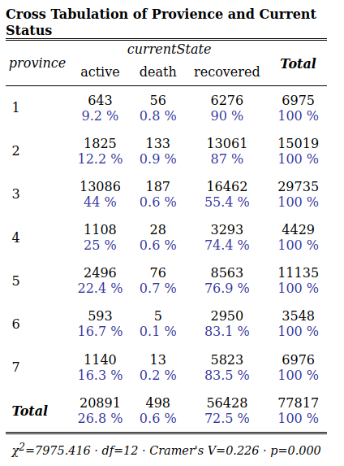

```r
#library(sjPlot)
#sjPlot::tab_xtab(var.row = covidtbl$province, var.col = covidtbl$currentState, title = "Cross Tabulation of Provience and Current Status", show.row.prc = TRUE)
```

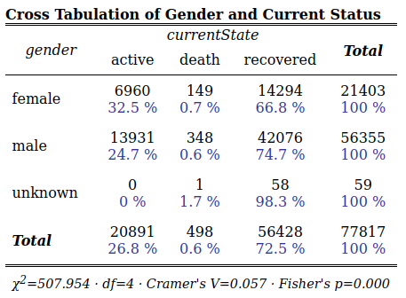

```r
#library(sjPlot)
#sjPlot::tab_xtab(var.row = covidtbl$gender, var.col = covidtbl$currentState, title = "Cross Tabulation of Gender and Current Status", show.row.prc = TRUE)
```

From above cross tabulation we can see that death rate was higher in female population however the total case number is higher in the males. ## cross-tabulation of age groups (row variable) and current status 17. Show the cross-tabulation of broad age groups (row variable) and current status (column variable) with row percentage and interpret the result carefully

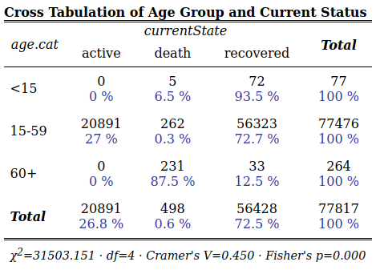

```r
#library(sjPlot)
#sjPlot::tab_xtab(var.row = covidtbl$age.cat, var.col = covidtbl$currentState, title = "Cross Tabulation of Age Group and Current Status", show.row.prc = TRUE)
```

From the table above we can see that the death rate is very high in the 60+ age group. This also shows that the very high (93.5%) of children recovered from covid. ## scatterplot of province (x-axis) and cleaned age (y-axis) 18. Show the scatterplot of province (x-axis) and cleaned age (y-axis) and get the appropriate correlation coefficient for this bi-variate data and interpret the result carefully

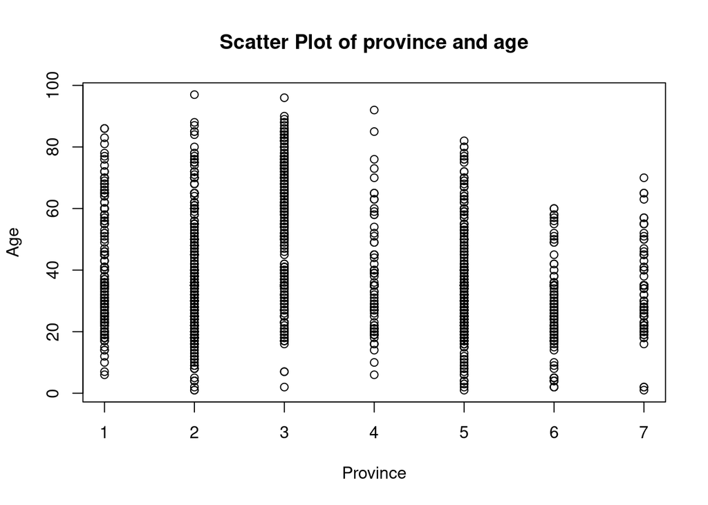

```r
plot(covidtbl$province,covidtbl$age, main = "Scatter Plot of province and age", xlab = "Province", ylab = "Age")
```

From the scatterplot above we can see that in Province 2, 3 and 4 older population got infected. In all the provience people from 15 to 60 got more infected. ## Show the scatterplot of age and diff1 19. Show the scatterplot of age (x-axis) and diff1 (y-axis) and get the appropriate correlation coefficient for this bi-variate data and interpret the result carefully

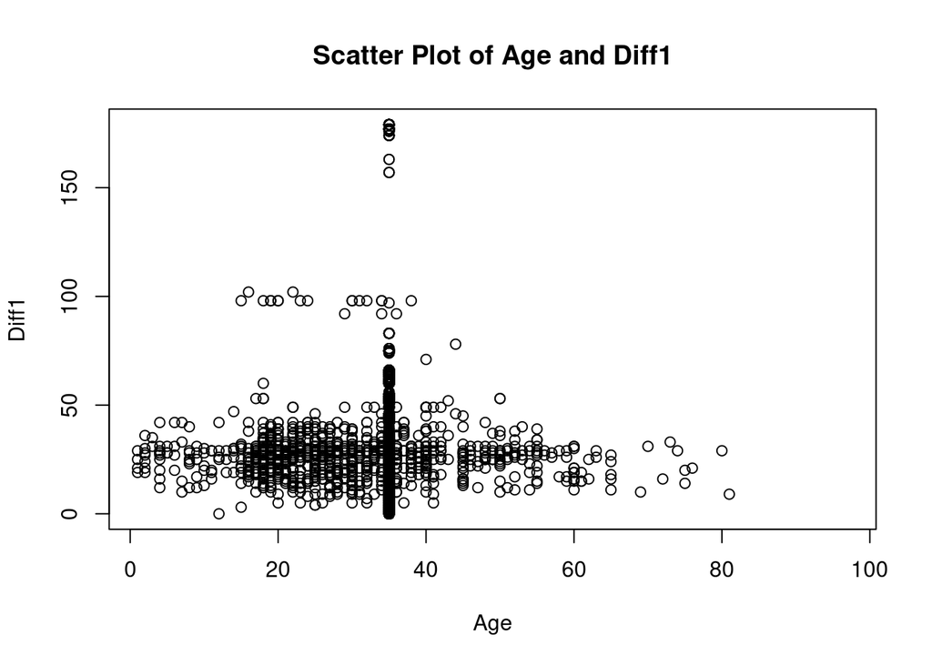

```r
plot(covidtbl$age,covidtbl$diff1, main = "Scatter Plot of Age and Diff1", xlab = "Age", ylab = "Diff1")
```

From the scatter plot we can see that the number of days between recovered and reported dates was higher for the age group around 35 to 40. This is to be expected as the average age was around 35.

## SWOT Analysis)

20. Summarize your learning using SWOT analysis to complete this project in a 2x2 table; be honest and specific so that I can learn from you too